# Lab 6: Nothing is Normal About This!

Samantha Cavalli and Bri Cirillo

9 April 2020

```r
#install.packages("Deriv")
library(Deriv)
```

https://github.com/s1173652/Lab6

# Part I: The Rightful pgauss()

## Problem 1

```r
#' Compute F(x) for a Gaussian random variable
#' @param x a vector of values to be evaluated at
#' @param mean the mean of the random variable
#' @param var the variance of the random variable
#'
#' @return the cumulative distribution function evaluated at all the values of x

x<- c(1,2,3)

pgauss <- function(x,mean=0, var=1){

  cum.vector <- vector(length = length(x))

  for (i in 1:length(x)) {

  cum.vector[i] <- integrate(f=function(x) dnorm(x,0,1), lower= -Inf, upper= x[i])[[1]]


  }

  return(cum.vector)
}

pgauss(x,mean=0,var=1)
```

```
[1] 0.8413448 0.9772499 0.9986501
```

```r
#testing the function to understand how it works
```

## Problem 2

```r
pgauss(3, mean=1, var=2)
```

```
[1] 0.9986501
```

```r
#finding the probability that a Gaussian RV with mean µ = 1 and variance = 2 exceeds 3
```

```r
pnorm(q=3,mean=0,sd=1)
```

```
[1] 0.9986501
```

```r
# using pnorm to check our prior result using pgauss
```

We can verify our result using pnorm and get the same answer.

# Part II: What’s a Normal Score?

## Problem 3

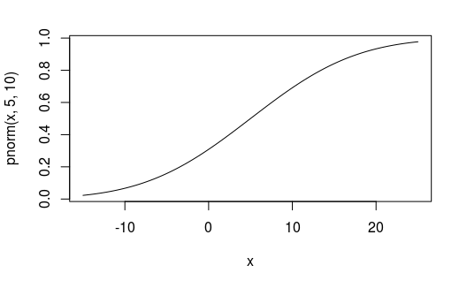

```r
curve(pnorm(x,5,10), from = -15, to= 25)
```

```r
# plotting a cdf curve for a Gaussian RV with mean=5 and var=100
```

It looks like the 0.25 quantile of this distribution is at is about -2.

## Problem 4

```r
#' Compute the quantile function for a Gaussian random variable
#' @param q a vector of values to be evaluated at
#' @param mean the mean of the random variable
#' @param var the variance of the random variable
#'
#' @return the cumulative distribution function evaluated at all the values of x

qgauss <- function(q, mean=0, var=1){

  quant.vector <- vector(length = length(q))

  for (i in 1: length(q)){
    f <- function(x) pgauss(x, mean,var) - q[i]
     quant.vector[i] <- uniroot(f, c(mean-3*sqrt(var), mean+3*sqrt(var)))[[1]]

  }

 return(quant.vector)
}

qgauss(.25,mean=0,var=1)
```

```
[1] -0.6745096
```

```r
#testing qguass to better understand the function
```

## Problem 5

```r
qgauss(0.25, mean = 5, var = 100)
```

```
Error in uniroot(f, c(mean - 3 * sqrt(var), mean + 3 * sqrt(var))) :
  f() values at end points not of opposite sign
```

# Part III: What’s the Most Likely Mean?

## Problem 6

```r
#' Compute the log-likelihood function for a Gaussian random variable
#' @param mean the mean of the random variable
#' @param var the variance of the random variable
#' @param data a vector of values to be evaluated at
#'
#' @return the cumulative distribution function evaluated at all the values of x

data <- c(1,2,3)

gaussian.ll <- function(mean,var,data){

     n <- length(data)

    sum.data <- sum((data-mean)^2)

    ll <- -(n/2)*log(2*pi*var)-(1/(2*var))*(sum.data)

  return(ll)
}

gaussian.ll(data=c(1,2,3), mean=0, var=1)
```

```
[1] -9.756816
```

```r
#testing guassian.11 to better understand the function
```

## Problem 7

```r
gaussian.ll.v <- Vectorize(gaussian.ll, vectorize.args = 'mean')

# vectorizing the mean argument
```

The mean argument is vectorized.

## Problem 8

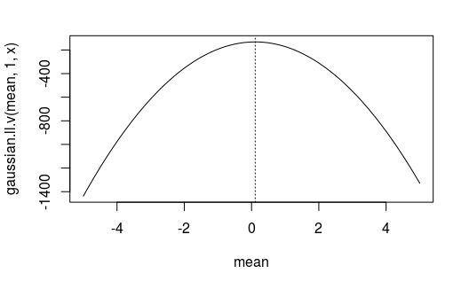

```r
set.seed(1)

x <- rnorm(100, mean = 0, sd = 1)

# creating a random sample of 100 from a Gaussian distribution

curve(gaussian.ll.v(mean,1,x), from = -5, to = 5, xname= 'mean')
abline(v=0.1088874, lty =3)
```

```r
# plot of the log-likelihood function
```

The value of the mean that maximizes the log-likelihood is around 0. This makes sense given that we generated the sample with a normal distribution, where the standard mean is 0 and the MLE of a normal random variable is the sample mean.

## Problem 9

```r
optimize(gaussian.ll.v,var=1, data= x, interval=c(-5,5),maximum = TRUE)
```

```
$maximum
[1] 0.1088874

$objective
[1] -131.8286
```

```r
# finding the value of the mean that maximizes the log-liklihood function
```

The maximum likelihood estimator for the function is 0.1089.

## Problem 10

```r
mean(x)
```

```
[1] 0.1088874
```

```r
# computing the mean of x
```

The mean of x is equal to 0.1089, which is the same maximizer found in problem 9. This result is what we would expect since the MLE of a normal random sample is the sample mean.